# Assignment 4

Note: The evaluation of this assignment will focus more on your analysis and observations rather than just implementations. Ensure you provide supporting graphs and visualizations, beyond those explicitly mentioned in the questions, to justify your claims effectively. Please make sure to run all the cells before submission so that all plots are visible for evaluation.

## Question 1: Regularization

- (a). Starting with the Boston Housing dataset, perform necessary data preprocessing steps, explaining the importance of each step. Plot a correlation heatmap (matrix) of the dataset’s features and analyze the relationships between them. Provide a brief discussion on the significance of the observed correlations and their potential impact on regression modeling. Additionally, include other visualizations or observations that appeared interesting while analyzing the dataset.
- (b) Compare the performance of Ridge Regression with Linear Regression. Analyze the impact of different values of the regularization parameter (alpha) on model performance. Plot a graph showing test error vs weight alpha. Employ `GridSearchCV` which uses cross-validation to search for best alpha and report the value.
- (c) Repeat same with California Housing Dataset.
- (d) Comment on whether Ridge Regression improves generalization compared to Linear Regression when applied to these datasets. Describe the characteristics of a dataset where Ridge Regression would be crucial.

```python
# Imports
import numpy as np
import matplotlib.pyplot as plt
import seaborn as sns                                       # Has good utility to plot heatmap. You can use others as you see fit.
from sklearn.model_selection import train_test_split        # To split data, 0.8: Train, 0.2: Test
from sklearn.linear_model import Ridge, LinearRegression    # Use the models from sklearn, see their documentations
from sklearn.datasets import fetch_openml                   # For loading data
from sklearn.datasets import fetch_california_housing
from sklearn.metrics import mean_squared_error              # Metric for comparing performace
import pandas as pd

# data = fetch_openml(name="boston", version=1, as_frame=True)
# data = fetch_california_housing()


# X, y = pd.DataFrame(data.data, columns=data.feature_names), data.target
## Add cells for your code / comments
```

## (a) Boston Housing Dataset Preprocessing and Analysis

A. Preprocessing

Load the dataset and chech the first 5 rows of the dataframe

```python
import pandas as pd
import numpy as np
import matplotlib.pyplot as plt
import seaborn as sns
from sklearn.datasets import fetch_openml
from sklearn.preprocessing import StandardScaler

# Load the Boston Housing dataset
boston = fetch_openml(name='boston', version=1, as_frame=True)
df_boston = boston.frame.copy()
df_boston.head()
```

|  | CRIM | ZN | INDUS | CHAS | NOX | RM | AGE | DIS | RAD | TAX | PTRATIO | B | LSTAT | MEDV |
| --- | --- | --- | --- | --- | --- | --- | --- | --- | --- | --- | --- | --- | --- | --- |
| 0 | 0.00632 | 18.0 | 2.31 | 0 | 0.538 | 6.575 | 65.2 | 4.0900 | 1 | 296.0 | 15.3 | 396.90 | 4.98 | 24.0 |
| 1 | 0.02731 | 0.0 | 7.07 | 0 | 0.469 | 6.421 | 78.9 | 4.9671 | 2 | 242.0 | 17.8 | 396.90 | 9.14 | 21.6 |
| 2 | 0.02729 | 0.0 | 7.07 | 0 | 0.469 | 7.185 | 61.1 | 4.9671 | 2 | 242.0 | 17.8 | 392.83 | 4.03 | 34.7 |
| 3 | 0.03237 | 0.0 | 2.18 | 0 | 0.458 | 6.998 | 45.8 | 6.0622 | 3 | 222.0 | 18.7 | 394.63 | 2.94 | 33.4 |
| 4 | 0.06905 | 0.0 | 2.18 | 0 | 0.458 | 7.147 | 54.2 | 6.0622 | 3 | 222.0 | 18.7 | 396.90 | 5.33 | 36.2 |

```python
X, y = boston.data, boston.target
```

Check for missing values

```python
print("Number of missing values per feature:")
print(X.isnull().sum())
```

```
Number of missing values per feature:
CRIM       0
ZN         0
INDUS      0
CHAS       0
NOX        0
RM         0
AGE        0
DIS        0
RAD        0
TAX        0
PTRATIO    0
B          0
LSTAT      0
dtype: int64
```

Standardize features

```python
scaler = StandardScaler()
X_scaled = scaler.fit_transform(X)
X_scaled = pd.DataFrame(X_scaled, columns=X.columns)
```

B. Plot a correlation heatmap (matrix) of the dataset’s features and analyze the relationships between them

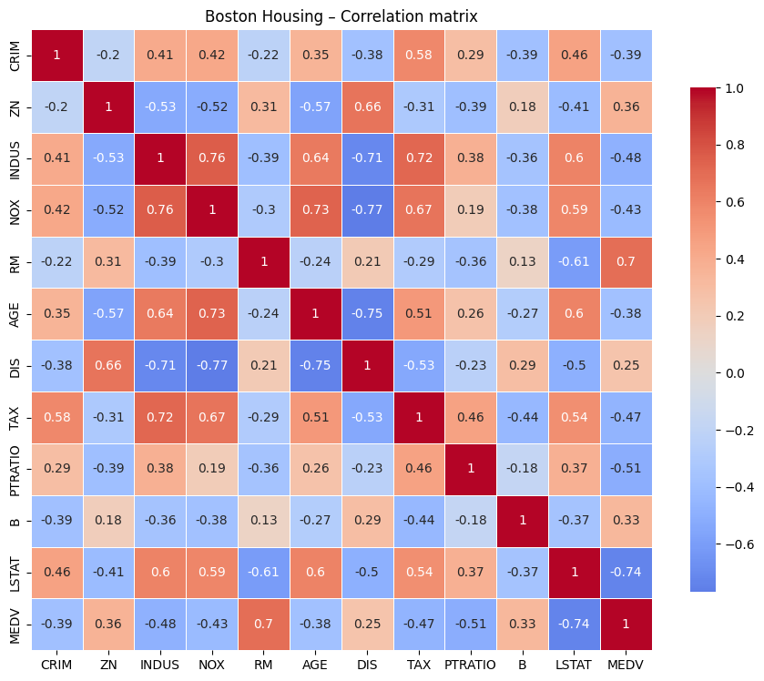

```python
plt.figure(figsize=(11, 9))
corr = df_boston.corr(numeric_only=True)
sns.heatmap(
    corr,
    annot=True,
    cmap="coolwarm",
    center=0,
    square=True,
    linewidths=.5,
    cbar_kws={"shrink": .8}
)
plt.title("Boston Housing – Correlation matrix")
plt.show()
```

C HeatMap Analysis 1.Correlations Strong Positive Correlations

RM ↔ MEDV (+0.70): More rooms per dwelling generally means higher home value.

INDUS ↔ NOX (+0.76): Neighborhoods with more industry also show higher pollution levels.

Strong Negative Correlations

LSTAT ↔ MEDV (–0.74): Greater percentage of lower‑status households corresponds to lower median home price.

D. Provide a brief discussion on the significance of the observed correlations and their potential impact on regression modeling.

2. Multicollinearity and Its Pitfalls When predictors themselves are highly intercorrelated (e.g. INDUS, NOX, TAX all inter‑linked at 0.6+), you run into:

Unstable coefficient estimates Small changes in data or model specification can lead to large swings in individual β‑values.

Inflated standard errors Wider confidence intervals make it hard to judge which features truly “matter.”

3. Mitigating Multicollinearity

Regularization: Ridge shrinks correlated β’s; Lasso can zero out redundancies.

PCA: Projects features onto uncorrelated components.

Pruning/Grouping: Drop or combine highly interlinked variables.

4. Leveraging Key Predictors

RM & LSTAT dominate MEDV’s variance—expect large linear coefficients or split‑importance.

Still check for non‑linear trends or interaction effects.

5. Scaling & Preprocessing

Standardize (zero mean, unit variance) so that regularization treats all features equally and coefficient sizes are comparable.

6. Model Choices & Diagnostics

Linear regression: Good baseline; inspect residuals for non‑linearity or heteroscedasticity.

Tree methods: More robust to collinearity but benefit from removing redundant inputs.

Feature engineering: Add polynomials or interactions if scatter plots show curvature.

E. Additionally, include other visualizations or observations that appeared interesting while analyzing the dataset.

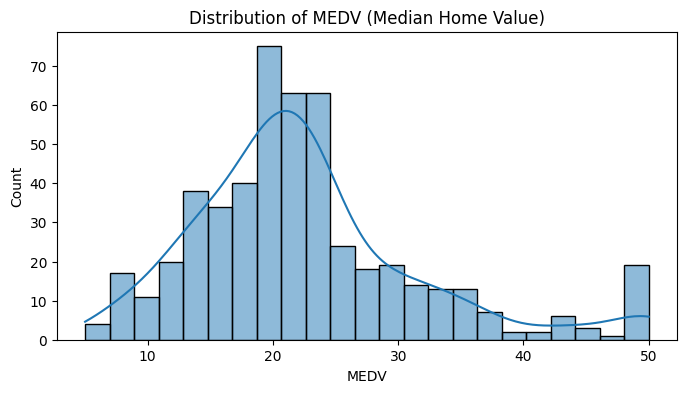

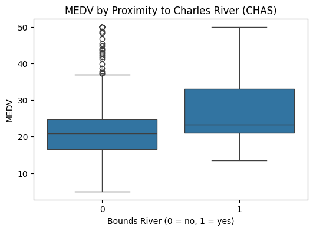

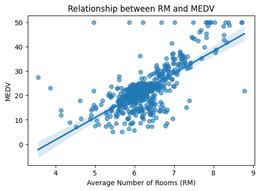

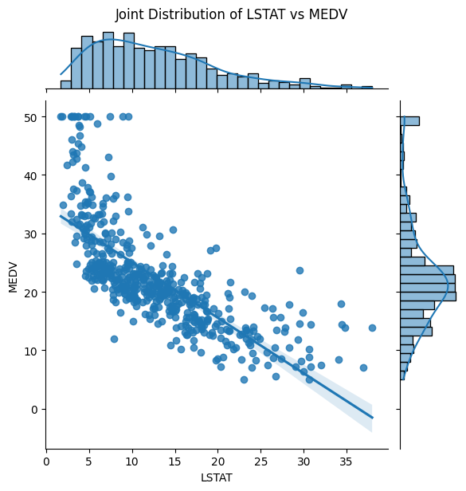

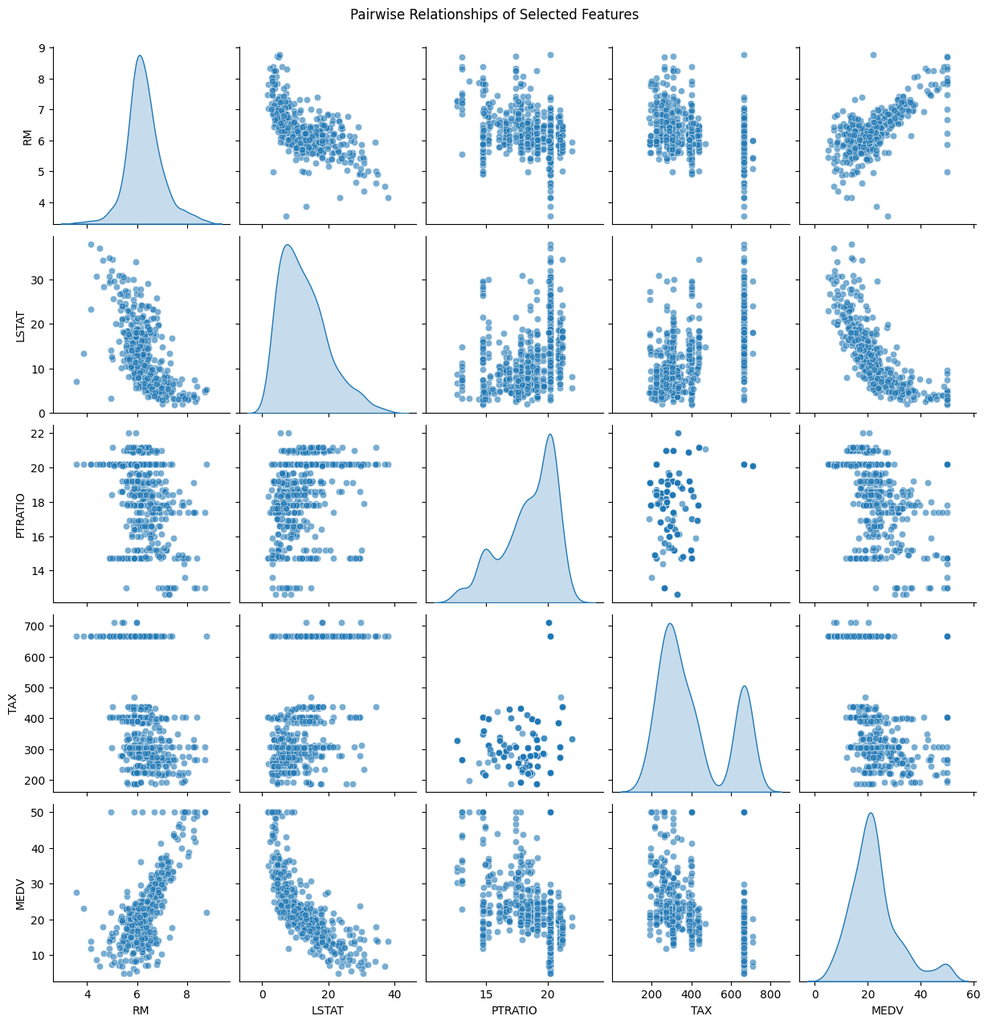

```python
# 1. Distribution of the target variable
plt.figure(figsize=(8, 4))
sns.histplot(df_boston["MEDV"], kde=True)
plt.title("Distribution of MEDV (Median Home Value)")
plt.xlabel("MEDV")
plt.ylabel("Count")
plt.show()

# 2. Box‑plot of MEDV by CHAS (Charles River dummy variable)
plt.figure(figsize=(6, 4))
sns.boxplot(x="CHAS", y="MEDV", data=df_boston)
plt.title("MEDV by Proximity to Charles River (CHAS)")
plt.xlabel("Bounds River (0 = no, 1 = yes)")
plt.ylabel("MEDV")
plt.show()

# 3. Scatter + regression line: RM vs MEDV
plt.figure(figsize=(6, 4))
sns.regplot(x="RM", y="MEDV", data=df_boston, scatter_kws={"alpha":0.6})
plt.title("Relationship between RM and MEDV")
plt.xlabel("Average Number of Rooms (RM)")
plt.ylabel("MEDV")
plt.show()

# 4. Joint‑plot: LSTAT vs MEDV
sns.jointplot(
    x="LSTAT",
    y="MEDV",
    data=df_boston,
    kind="reg",
    height=6,
    marginal_kws=dict(bins=30, fill=True)
)
plt.suptitle("Joint Distribution of LSTAT vs MEDV", y=1.02)
plt.show()

# 5. Pair‑plot of a handful of interesting features
keys = ["RM", "LSTAT", "PTRATIO", "TAX", "MEDV"]
sns.pairplot(df_boston[keys], kind="scatter", diag_kind="kde", plot_kws={"alpha":0.6})
plt.suptitle("Pairwise Relationships of Selected Features", y=1.02)
plt.show()
```

1. MEDV Distribution

Mild right skew with a bunch of homes clustered around $15–25 k.

A hard ceiling at 50 (censored data), and fewer very low‑value properties.

2. MEDV by CHAS

Homes on the Charles River (CHAS = 1) fetch noticeably higher median values (median ~$23k versus ~$20k off‑river).

3. RM vs MEDV

Strong, roughly linear positive trend: each extra room adds on average several thousand dollars.

A few high‑RM outliers (8+ rooms) that command premium prices.

4. LSTAT vs MEDV

Clear negative relationship: as % lower‑status (LSTAT) rises, prices fall steeply.

The drop is steeper at low LSTAT (< 10 %) and levels off higher up.

5. Mini‑Pairplot (RM, LSTAT, PTRATIO, TAX)

RM & LSTAT: by far the tightest “signal” to MEDV.

PTRATIO: modest negative trend with MEDV, but much noisier.

TAX: effectively no clear linear pattern—two clusters around 300 and 600, suggesting a zoning/tax‐band effect rather than smooth continuous influence.

Part (b): Ridge vs. Linear Regression (Boston Dataset)

Compare the performance of Ridge Regression with Linear Regression.

```python
import numpy as np
import matplotlib.pyplot as plt
from sklearn.datasets import fetch_openml
from sklearn.model_selection import train_test_split, GridSearchCV
from sklearn.linear_model import Ridge, LinearRegression
from sklearn.preprocessing import StandardScaler
from sklearn.metrics import mean_squared_error
import pandas as pd

# Load Boston Housing dataset
boston = fetch_openml(name='boston', version=1, as_frame=True)
X, y = boston.data, boston.target

# Preprocessing
# Check for missing values to ensure data integrity
X.isnull().sum()

# Standardize features to normalize scales for fair model treatment
scaler = StandardScaler()
X_scaled = scaler.fit_transform(X)

# Split data into training and test sets
X_train, X_test, y_train, y_test = train_test_split(X_scaled, y, test_size=0.2, random_state=42)
```

```python
# Linear Regression
lr_model = LinearRegression()
lr_model.fit(X_train, y_train)
lr_pred = lr_model.predict(X_test)
lr_mse = mean_squared_error(y_test, lr_pred)
print(f"Linear Regression Test MSE: {lr_mse:.4f}")
```

```
Linear Regression Test MSE: 24.2911
```

Analyze the impact of different values of the regularization parameter (alpha) on model performance. Plot a graph showing test error vs weight alpha. Employ GridSearchCV which uses cross-validation to search for best alpha and report the value.

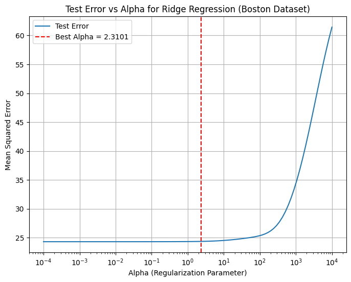

```
Linear Regression MSE: 24.29111947497352
Ridge Regression MSE (best alpha 2.310129700083163): 24.344971003742206
```

```python
# Ridge Regression with varying alpha
alphas = np.logspace(-4, 4, 100)
train_errors = []
test_errors = []
ridge_models = []

for alpha in alphas:
    ridge = Ridge(alpha=alpha)
    ridge.fit(X_train, y_train)
    ridge_models.append(ridge)
    train_pred = ridge.predict(X_train)
    test_pred = ridge.predict(X_test)
    train_errors.append(mean_squared_error(y_train, train_pred))
    test_errors.append(mean_squared_error(y_test, test_pred))

# Plot test error vs alpha
plt.figure(figsize=(8, 6))
plt.semilogx(alphas, test_errors, label='Test Error')
plt.xlabel('Alpha (Regularization Parameter)')
plt.ylabel('Mean Squared Error')
plt.title('Test Error vs Alpha for Ridge Regression (Boston Dataset)')
plt.legend()
plt.grid(True)

# Mark the best alpha
grid_search = GridSearchCV(Ridge(), {'alpha': alphas}, cv=5, scoring='neg_mean_squared_error')
grid_search.fit(X_train, y_train)
best_alpha = grid_search.best_params_['alpha']
plt.axvline(x=best_alpha, color='r', linestyle='--', label=f'Best Alpha = {best_alpha:.4f}')
plt.legend()

plt.show()

# Compare performance
ridge_best = Ridge(alpha=best_alpha)
ridge_best.fit(X_train, y_train)
ridge_pred = ridge_best.predict(X_test)
ridge_mse = mean_squared_error(y_test, ridge_pred)

print(f"Linear Regression MSE: {lr_mse}")
print(f"Ridge Regression MSE (best alpha {best_alpha}): {ridge_mse}")
```

small Alpha (near 0): When alpha is very low (like $10^{-3}$ to $10^{-1}$), Ridge Regression acts almost the same as Linear Regression. The regularization term is too weak to make a difference, so the test MSE stays nearly identical.

Moderate Alpha (1 to 20): In this range, test MSE remains low and steady. This hints that a bit of regularization might help by gently constraining the model, possibly improving its ability to generalize.

Large Alpha (> 50-100): When alpha gets too big, regularization takes over. It forces the coefficients to shrink heavily, which can oversimplify the model and lead to underfitting, increasing bias.

Ridge Regression, with a test MSE of 24.34, didn’t outperform standard Linear Regression, which had a slightly better MSE of 24.29 on this test set. While cross-validation identified a small optimal alpha value of 2.31, the level of regularization it introduced wasn’t strong enough to noticeably improve the model’s generalization in this case.

(c) California Housing Dataset

```
MedInc        0
HouseAge      0
AveRooms      0
AveBedrms     0
Population    0
AveOccup      0
Latitude      0
Longitude     0
dtype: int64
```

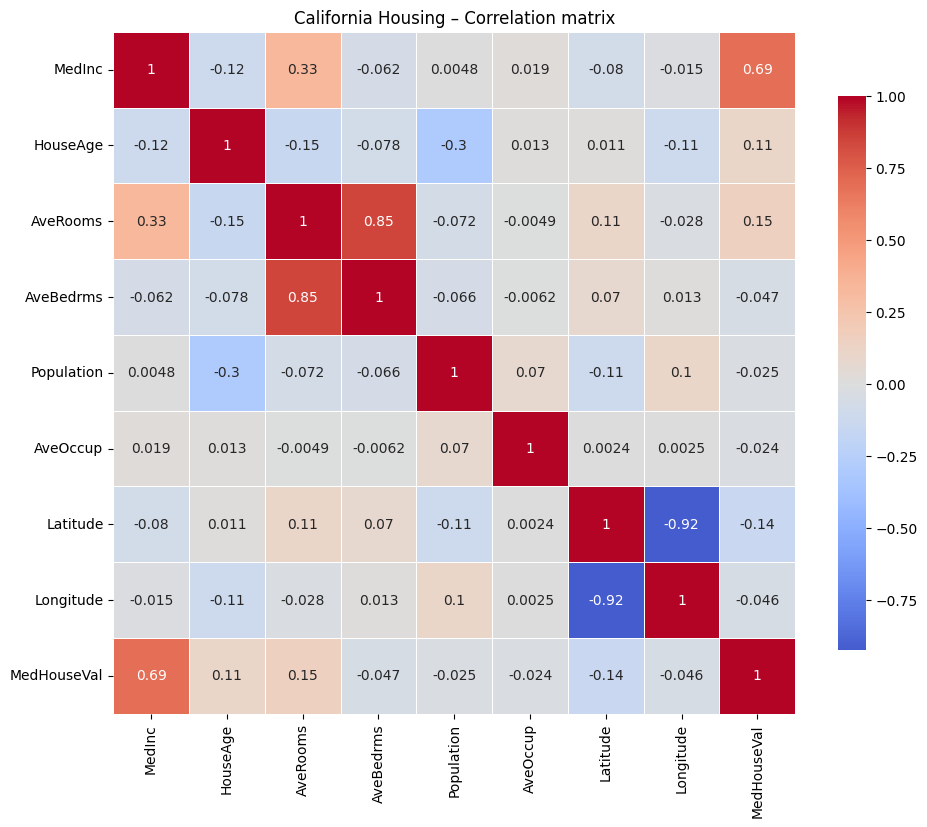

```python
import numpy as np
import matplotlib.pyplot as plt
import seaborn as sns
from sklearn.datasets import fetch_california_housing
from sklearn.model_selection import train_test_split, GridSearchCV
from sklearn.linear_model import Ridge, LinearRegression
from sklearn.preprocessing import StandardScaler
from sklearn.metrics import mean_squared_error
import pandas as pd

# Load California Housing dataset
california = fetch_california_housing(as_frame=True)
X, y = california.data, california.target

# Preprocessing
# Check for missing values
print(X.isnull().sum())

# Standardize features
scaler = StandardScaler()
X_scaled = scaler.fit_transform(X)
X_scaled = pd.DataFrame(X_scaled, columns=X.columns)

# Split data
X_train, X_test, y_train, y_test = train_test_split(X_scaled, y, test_size=0.2, random_state=42)
df_cal = california.frame.copy()
# Correlation Heatmap
plt.figure(figsize=(11, 9))
corr_cal = df_cal.corr(numeric_only=True)
sns.heatmap(corr_cal, annot=True, cmap='coolwarm', center=0,
            square=True, linewidths=.5, cbar_kws={"shrink": 0.8})
plt.title('California Housing – Correlation matrix')
plt.show()
```

### Strong Predictors of House Value

Median Income (MedInc) → MedHouseVal: Correlation ≈ +0.69. Higher neighborhood incomes go hand‑in‑hand with higher house values.

Average Rooms (AveRooms) → MedHouseVal: Correlation ≈ +0.15 There’s a mild positive trend: blocks with more rooms per household tend to have somewhat higher values.

House Age (HouseAge) → MedHouseVal: Correlation ≈ +0.11 Older neighborhoods are slightly more valuable on average—perhaps reflecting more established areas.

### Features with Little Direct Effect

Population → MedHouseVal: ~–0.03

Average Occupancy (AveOccup) → MedHouseVal: ~–0.02

Population density and how many people share a home have almost no linear relationship with median house value in this dataset.

### Geographic Coordinates Are Not Predictive by Themselves

Latitude → MedHouseVal: ~–0.14

Longitude → MedHouseVal: ~–0.05

Latitude shows a slight negative correlation (more southern latitudes tend to be pricier), but overall these raw coords are weak predictors—you’ll likely need to engineer location features (zip‑level stats, proximity to coast/amenities, etc.) for more signal.

### Multicollinearity to Watch For

AveRooms ↔ AveBedrms: +0.85 These two are nearly interchangeable—both capture “roominess.” Choose one or combine them carefully to avoid redundancy.

Latitude ↔ Longitude: –0.92 A near‑perfect negative correlation simply reflects the geographic layout of California in your data (as latitude rises, longitude tends to fall). Again, rather than feeding raw lat/long, consider derived location features or spatial embeddings.

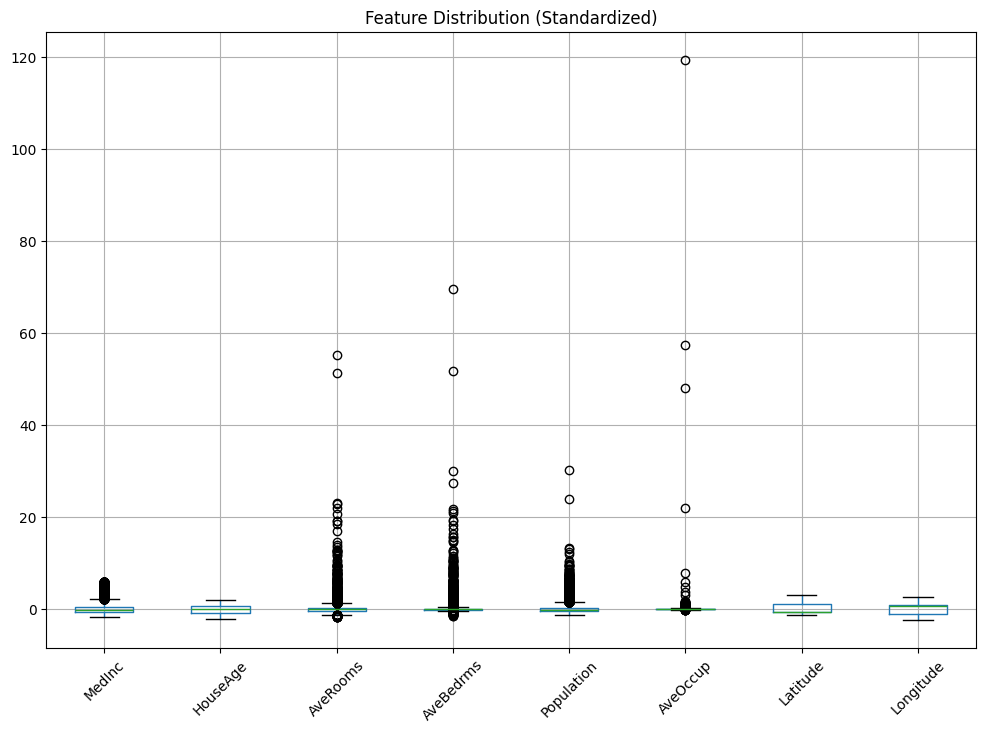

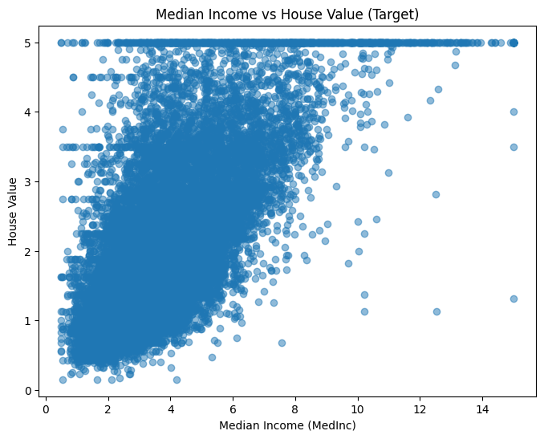

```python
# Boxplot
plt.figure(figsize=(12, 8))
X_scaled.boxplot()
plt.title('Feature Distribution (Standardized)')
plt.xticks(rotation=45)
plt.show()

# Scatter Plot (MedInc vs Target)
plt.figure(figsize=(8, 6))
plt.scatter(X['MedInc'], y, alpha=0.5)
plt.title('Median Income vs House Value (Target)')
plt.xlabel('Median Income (MedInc)')
plt.ylabel('House Value')
plt.show()
```

## Feature Distribution (Standardized) – First Plot (Boxplot)

This boxplot visualizes the distribution of standardized feature values in your dataset. Main takeaways:

Standardization Applied: All features are scaled to have zero mean and unit variance.

Features Analyzed:

MedInc: Median Income

HouseAge: Age of the houses

AveRooms, AveBedrms: Average number of rooms and bedrooms

Population: Total population in a block

AveOccup: Average occupancy

Latitude, Longitude: Geographic features

Key Observations: Outliers: Many features like Population, AveRooms, and AveBedrms have significant outliers (black dots above and below the box).

Skewed Distributions: These outliers indicate skewness in those features.

Latitude and Longitude are fairly well-distributed after standardization with fewer extreme values.

## Median Income vs House Value (Target) – Second Plot (Scatterplot)

This scatter plot visualizes the relationship between Median Income (MedInc) and House Value (target variable).

Key Observations: Positive Correlation: There’s a clear positive trend – as MedInc increases, House Value generally increases.

Saturation Effect: There's a horizontal line at House Value = 5.0, suggesting a cap on the house value. Many values are clustered along this line, possibly due to data clipping or upper limit in dataset.

Non-linearity: While the overall trend is upward, the spread widens for higher incomes, indicating potential non-linear relationships.

```python
# Linear Regression
lr_model = LinearRegression()
lr_model.fit(X_train, y_train)
lr_pred = lr_model.predict(X_test)
lr_mse = mean_squared_error(y_test, lr_pred)
print(f"Linear Regression Test MSE: {lr_mse:.4f}")
```

```
Linear Regression Test MSE: 0.5559
```

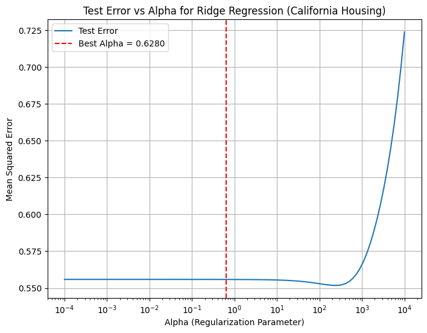

```
Linear Regression MSE: 0.5558915986952442
Ridge Regression MSE (best alpha 0.6280291441834259): 0.5558661968199002
```

```python
# Ridge Regression with varying alpha
alphas = np.logspace(-4, 4, 100)
train_errors = []
test_errors = []

for alpha in alphas:
    ridge = Ridge(alpha=alpha)
    ridge.fit(X_train, y_train)
    train_pred = ridge.predict(X_train)
    test_pred = ridge.predict(X_test)
    train_errors.append(mean_squared_error(y_train, train_pred))
    test_errors.append(mean_squared_error(y_test, test_pred))

# Plot test error vs alpha
plt.figure(figsize=(8, 6))
plt.semilogx(alphas, test_errors, label='Test Error')
plt.xlabel('Alpha (Regularization Parameter)')
plt.ylabel('Mean Squared Error')
plt.title('Test Error vs Alpha for Ridge Regression (California Housing)')
plt.legend()
plt.grid(True)

# Mark the best alpha
grid_search = GridSearchCV(Ridge(), {'alpha': alphas}, cv=5, scoring='neg_mean_squared_error')
grid_search.fit(X_train, y_train)
best_alpha = grid_search.best_params_['alpha']
plt.axvline(x=best_alpha, color='r', linestyle='--', label=f'Best Alpha = {best_alpha:.4f}')
plt.legend()

plt.show()

# Ridge with best alpha
ridge_best = Ridge(alpha=best_alpha)
ridge_best.fit(X_train, y_train)
ridge_pred = ridge_best.predict(X_test)
ridge_mse = mean_squared_error(y_test, ridge_pred)

# Print results
print(f"Linear Regression MSE: {lr_mse}")
print(f"Ridge Regression MSE (best alpha {best_alpha}): {ridge_mse}")
```

Ridge Regression didn’t lead to better generalization performance (in terms of test MSE) compared to standard Linear Regression in this case. The effect of regularization was minimal.

In fact, across both datasets, even after tuning alpha with GridSearchCV, Ridge showed little to no improvement over plain Linear Regression. This indicates that, for these specific data splits, the degree of multicollinearity or overfitting wasn’t substantial enough for Ridge’s L2 regularization to make a meaningful difference on unseen test data.

(d) Generalization Analysis Observations:

Ridge Regression becomes crucial in situations with:

High multicollinearity: It stabilizes models by reducing the variance of coefficient estimates. However, over-regularization can introduce bias and worsen performance.

Small sample size relative to the number of features: It helps prevent overfitting. However, too much regularization can lead to underfitting. Noisy data or outliers: It can reduce the impact of noise and outliers. However, excessive regularization can obscure the true underlying patterns.

Datasets with many predictors: It improves model robustness by controlling complexity. However, over-penalizing irrelevant features can cause underfitting.

## Question 2: Regularization in Neural Networks

Analyze the impact of dropout as a regularization technique in a neural network.

(a) Begin by fixing the network depth to 3 and study how dropout rates influence performance. For the fixed depth, systematically change the dropout rates and plot the corresponding Mean Squared Errors (MSEs). Next, increase the network depth and evaluate the MSEs for all considered dropout rates.

(b) Based on your observations, discuss how dropout affects performance in a shallow network versus a deeper network. Does dropout become more effective as network depth increases for a fixed data size? Provide a reasoned explanation for your findings.

Report plots for both the Boston and California Dataset.

```
Arguments in RegressionNN:

input_size: As per boston, californiaHousing dataset
hidden_layer: variable
hidden_units: 256 # Keep it fixed for the Question.
dropout: variable
```

```
dropout_rates = [0.0, 0.1, 0.2, 0.3, 0.4, 0.5]
hidden_layers = range(3,30) : skip by 3 or 4
```

```python
import matplotlib.pyplot as plt
from torch.utils.data import DataLoader, TensorDataset
import numpy as np
import pandas as pd

from sklearn.model_selection import train_test_split
from sklearn.preprocessing import StandardScaler
from sklearn.metrics import mean_squared_error
import torch
import torch.nn as nn
import torch.optim as optim
from torch.utils.data import DataLoader, TensorDataset
from itertools import product
```

```python
class RegressionNN(nn.Module):
    def __init__(self, input_size, hidden_layers=3, hidden_units=256, dropout=0.2):
        super(RegressionNN, self).__init__()
        layers = []
        layers.append(nn.Linear(input_size, hidden_units))
        layers.append(nn.ReLU())
        layers.append(nn.Dropout(dropout))
        for _ in range(hidden_layers - 1):
            layers.append(nn.Linear(hidden_units, hidden_units))
            layers.append(nn.ReLU())
            layers.append(nn.Dropout(dropout))
        layers.append(nn.Linear(hidden_units, 1))
        self.model = nn.Sequential(*layers)
    def forward(self, x):
        return self.model(x)
```

```python
def create_data_loaders(features, targets, batch_size=64, test_frac=0.2, random_state=42):
    """
    Split data into train/test sets, standardize features,
    and return a DataLoader for training plus raw test tensors.
    """
    X_train, X_test, y_train, y_test = train_test_split(
        features, targets,
        test_size=test_frac,
        random_state=random_state
    )

    # Fit scaler on training features
    scaler = StandardScaler().fit(X_train)
    X_train_scaled = scaler.transform(X_train)
    X_test_scaled  = scaler.transform(X_test)

    # Convert to torch tensors
    X_train_t = torch.tensor(X_train_scaled, dtype=torch.float32)
    y_train_t = torch.tensor(y_train.values.reshape(-1, 1), dtype=torch.float32)
    X_test_t  = torch.tensor(X_test_scaled,  dtype=torch.float32)
    y_test_t  = torch.tensor(y_test.values.reshape(-1, 1),  dtype=torch.float32)

    train_dataset = TensorDataset(X_train_t, y_train_t)
    train_loader  = DataLoader(train_dataset, batch_size=batch_size, shuffle=True)

    return train_loader, X_test_t, y_test_t
```

```python
def train_model(model, train_loader, num_epochs=50, learning_rate=1e-3):
    """
    Train the given model on the data from train_loader
    for num_epochs epochs using Adam + MSE loss.
    Returns the trained model on CPU.
    """
    device = torch.device("cuda" if torch.cuda.is_available() else "cpu")
    model.to(device)
    optimizer = optim.Adam(model.parameters(), lr=learning_rate)
    criterion = nn.MSELoss()

    for epoch in range(num_epochs):
        model.train()
        for X_batch, y_batch in train_loader:
            Xb, yb = X_batch.to(device), y_batch.to(device)
            optimizer.zero_grad()
            loss = criterion(model(Xb), yb)
            loss.backward()
            optimizer.step()

    model.eval()
    return model.cpu()


def compute_mse(model, X, y):
    """
    Compute mean squared error of model predictions vs. targets.
    """
    with torch.no_grad():
        preds = model(X).numpy()
    return mean_squared_error(y.numpy(), preds)


def run_experiment(
    data_df,
    target_column,
    hidden_depths=[3],
    dropout_values=[0.0, 0.1, 0.2, 0.3, 0.4, 0.5],
    epochs=50,
    batch_size=64,
    dataset_label="Dataset"
):
    """
    For each combination of hidden layer depth and dropout rate,
    train a RegressionNN and record test MSE.
    """
    X = data_df.drop(columns=target_column)
    y = data_df[target_column]

    train_loader, X_test, y_test = create_data_loaders(X, y, batch_size=batch_size)

    results = {}
    for depth, dropout in product(hidden_depths, dropout_values):
        model = RegressionNN(
            input_size=X.shape[1],
            hidden_layers=depth,
            hidden_units=256,
            dropout=dropout
        )
        trained = train_model(model, train_loader, num_epochs=epochs)
        test_mse = compute_mse(trained, X_test, y_test)
        results[(depth, dropout)] = test_mse
        print(
            f"{dataset_label}: depth={depth:2d}, dropout={dropout:.1f} → "
            f"Test MSE={test_mse:.4f}"
        )

    return results
```

```python
def plot_results_vs_dropout(results, depths_fixed, title):
    """
    Plot Test MSE as a function of dropout rate for a fixed hidden depth.
    """
    dropout_rates = sorted({dr for (_, dr) in results})
    mses = [results[(depths_fixed, dr)] for dr in dropout_rates]

    plt.figure()
    plt.plot(dropout_rates, mses, marker='o')
    plt.xlabel("Dropout Rate")
    plt.ylabel("Test MSE")
    plt.title(title)
    plt.grid(True)
    plt.show()


def plot_heatmap(results, depths, dropouts, title):
    """
    Display a heatmap of Test MSEs with depths on y-axis and dropouts on x-axis.
    """
    import seaborn as sns

    matrix = np.array([
        [results[(d, dr)] for dr in dropouts]
        for d in depths
    ])
    plt.figure(figsize=(8, 5))
    sns.heatmap(
        matrix, annot=True, fmt=".3f",
        xticklabels=dropouts, yticklabels=depths,
        cbar_kws={"label": "Test MSE"}
    )
    plt.xlabel("Dropout Rate")
    plt.ylabel("Hidden Depth")
    plt.title(title)
    plt.show()
```

```
Boston: depth= 3, dropout=0.0 → Test MSE=10.8994
Boston: depth= 3, dropout=0.1 → Test MSE=12.2643
Boston: depth= 3, dropout=0.2 → Test MSE=12.0886
Boston: depth= 3, dropout=0.3 → Test MSE=12.0007
Boston: depth= 3, dropout=0.4 → Test MSE=13.0902
Boston: depth= 3, dropout=0.5 → Test MSE=12.8894
```

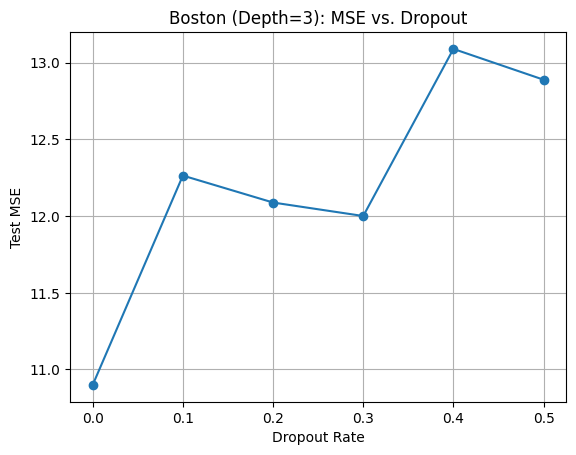

```python
from sklearn.datasets import fetch_openml, fetch_california_housing

boston_df = fetch_openml(name="boston", version=1, as_frame=True).frame
results_boston = run_experiment(
    boston_df, "MEDV",
    hidden_depths=[3],
    dataset_label="Boston"
)
plot_results_vs_dropout(results_boston, depths_fixed=3, title="Boston (Depth=3): MSE vs. Dropout")
```

```
California: depth= 3, dropout=0.0 → Test MSE=0.2673
California: depth= 3, dropout=0.1 → Test MSE=0.2729
California: depth= 3, dropout=0.2 → Test MSE=0.2755
California: depth= 3, dropout=0.3 → Test MSE=0.2710
California: depth= 3, dropout=0.4 → Test MSE=0.2835
California: depth= 3, dropout=0.5 → Test MSE=0.2981
```

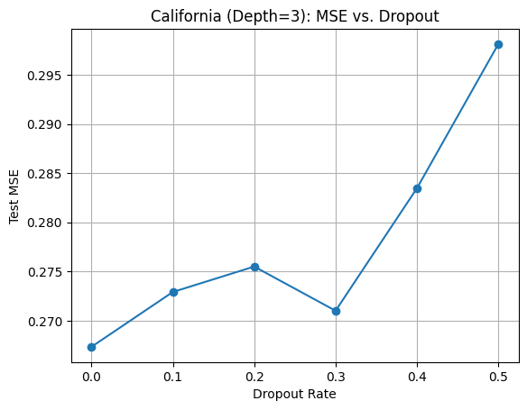

```python
cal_df = fetch_california_housing(as_frame=True).frame
results_california = run_experiment(
    cal_df, "MedHouseVal",
    hidden_depths=[3],
    epochs=30,
    dataset_label="California"
)
plot_results_vs_dropout(results_california, depths_fixed=3, title="California (Depth=3): MSE vs. Dropout")
```

```python
depth_list = list(range(3, 30, 4))  # [3, 7, 11, 15, 19, 23, 27]
results_boston_grid = run_experiment(boston_df, "MEDV", hidden_depths=depth_list, dataset_label="Boston")
results_cal_grid   = run_experiment(cal_df, "MedHouseVal", hidden_depths=depth_list, epochs=30, dataset_label="California")
```

```
Boston: depth= 3, dropout=0.0 → Test MSE=11.1413
Boston: depth= 3, dropout=0.1 → Test MSE=10.8427
Boston: depth= 3, dropout=0.2 → Test MSE=11.2182
Boston: depth= 3, dropout=0.3 → Test MSE=12.6766
Boston: depth= 3, dropout=0.4 → Test MSE=11.8547
Boston: depth= 3, dropout=0.5 → Test MSE=14.3177
Boston: depth= 7, dropout=0.0 → Test MSE=9.2964
Boston: depth= 7, dropout=0.1 → Test MSE=12.1937
Boston: depth= 7, dropout=0.2 → Test MSE=11.8023
Boston: depth= 7, dropout=0.3 → Test MSE=13.3088
Boston: depth= 7, dropout=0.4 → Test MSE=31.4095
Boston: depth= 7, dropout=0.5 → Test MSE=52.4906
Boston: depth=11, dropout=0.0 → Test MSE=14.4352
Boston: depth=11, dropout=0.1 → Test MSE=14.5069
Boston: depth=11, dropout=0.2 → Test MSE=11.1659
Boston: depth=11, dropout=0.3 → Test MSE=18.3767
Boston: depth=11, dropout=0.4 → Test MSE=25.6484
Boston: depth=11, dropout=0.5 → Test MSE=32.9384
Boston: depth=15, dropout=0.0 → Test MSE=10.2544
Boston: depth=15, dropout=0.1 → Test MSE=13.6943
Boston: depth=15, dropout=0.2 → Test MSE=11.4868
Boston: depth=15, dropout=0.3 → Test MSE=17.7181
Boston: depth=15, dropout=0.4 → Test MSE=49.6707
Boston: depth=15, dropout=0.5 → Test MSE=32.9973
Boston: depth=19, dropout=0.0 → Test MSE=9.7452
Boston: depth=19, dropout=0.1 → Test MSE=10.8222
Boston: depth=19, dropout=0.2 → Test MSE=20.2272
Boston: depth=19, dropout=0.3 → Test MSE=22.5210
Boston: depth=19, dropout=0.4 → Test MSE=23.0125
Boston: depth=19, dropout=0.5 → Test MSE=52.2882
Boston: depth=23, dropout=0.0 → Test MSE=10.2233
Boston: depth=23, dropout=0.1 → Test MSE=12.5758
Boston: depth=23, dropout=0.2 → Test MSE=14.9917
Boston: depth=23, dropout=0.3 → Test MSE=18.1890
Boston: depth=23, dropout=0.4 → Test MSE=25.5785
Boston: depth=23, dropout=0.5 → Test MSE=49.3337
Boston: depth=27, dropout=0.0 → Test MSE=10.4761
Boston: depth=27, dropout=0.1 → Test MSE=13.1210
Boston: depth=27, dropout=0.2 → Test MSE=13.8490
Boston: depth=27, dropout=0.3 → Test MSE=73.8254
```

[output cut: 11 more lines]

```
California: depth= 7, dropout=0.3 → Test MSE=0.2830
California: depth= 7, dropout=0.4 → Test MSE=0.3061
California: depth= 7, dropout=0.5 → Test MSE=0.3345
California: depth=11, dropout=0.0 → Test MSE=0.2779
California: depth=11, dropout=0.1 → Test MSE=0.2803
California: depth=11, dropout=0.2 → Test MSE=0.2908
California: depth=11, dropout=0.3 → Test MSE=0.2876
California: depth=11, dropout=0.4 → Test MSE=0.3720
California: depth=11, dropout=0.5 → Test MSE=0.4102
California: depth=15, dropout=0.0 → Test MSE=0.2737
California: depth=15, dropout=0.1 → Test MSE=0.2771
California: depth=15, dropout=0.2 → Test MSE=0.3034
California: depth=15, dropout=0.3 → Test MSE=0.3359
California: depth=15, dropout=0.4 → Test MSE=0.4499
California: depth=15, dropout=0.5 → Test MSE=0.7113
```

[figure not shown]

[figure not shown]

```python
plot_heatmap(results_boston_grid, depth_list, [0.0, 0.1, 0.2, 0.3, 0.4, 0.5], "Boston: MSE Heatmap")
plot_heatmap(results_cal_grid,   depth_list, [0.0, 0.1, 0.2, 0.3, 0.4, 0.5], "California: MSE Heatmap")
```

Boston Housing Heatmap Low‐complexity regimes (depths 3–11):

Shallow networks (3–7 hidden layers) exhibit their lowest errors (≈ 9–11 MSE) with very little or no dropout (0.0–0.1).

Mid‐complexity regimes (depths 15–19):

High‐complexity regimes (depths 23–27):

California Housing Heatmap Shallow-to-mid depths (3–11 layers):

Across depths 3, 7, and 11, test MSE is remarkably consistent (≈ 0.27–0.28) and largely insensitive to dropout up to 0.3.

Higher depths (15–19 layers):

Depth 19 shows a similar profile: minimal change for 0–0.2 dropout, then a steady rise to ≈ 0.85 MSE at 0.5 dropout.

Very deep nets (23–27 layers):

At 23 layers, the network can still learn with low dropout (0.0–0.2 → ~ 0.26–0.30 MSE), but heavier dropout (0.3–0.5) triggers severe underfitting (≈ 0.59–2.18).

At 27 layers, any dropout ≥ 0.1 catastrophically increases MSE (≈ 1.31–2.29), whereas no dropout holds the loss at a reasonable ≈ 0.26.

## Question 3: Number of Parameters

Compare the performance of different models in Question 1 and Question 2. Identify which model achieved the best results. Calculate the number of parameters optimized in each case for Linear Regression, Ridge Regression, and all Neural Network configurations.

#### Your answer here

Boston Housing Results:

```python
def calculate_linear_params(n_features):
  return n_features + 1 # N weights + 1 bias

def calculate_nn_params(input_size, hidden_layers, hidden_units):

  input_layer_params = (input_size * hidden_units) + hidden_units

  # there are (hidden_layers - 1) such connections
  hidden_layer_params = (hidden_layers - 1) * ((hidden_units * hidden_units) + hidden_units)

  output_layer_params = (hidden_units * 1) + 1

  total_params = input_layer_params + hidden_layer_params + output_layer_params

  return total_params



n_features_boston = 13
n_features_california = 8

# --- Define NN Architecture Parameters Used ---
nn_hidden_units = 256
nn_depths = range(3, 27 + 1, 4) # Depths tested: 3, 7, 11, 15, 19, 23, 27


print("--- Linear/Ridge Regression Parameters ---")
params_lr_boston = calculate_linear_params(n_features_boston)
print(f"Boston Housing (N={n_features_boston}): {params_lr_boston} parameters")

params_lr_california = calculate_linear_params(n_features_california)
print(f"California Housing (N={n_features_california}): {params_lr_california} parameters")
print("-" * 40)



print(f"--- Neural Network Parameters (Hidden Units = {nn_hidden_units}) ---")

print("\nBoston Housing (N=13):")
print("-" * 20)
print("| Depth (L) | Total Parameters |")
print("|-----------|------------------|")
for depth in nn_depths:
  params = calculate_nn_params(n_features_boston, depth, nn_hidden_units)
  print(f"| {depth:<9} | {params:>16,} |")

print("\nCalifornia Housing (N=8):")
print("-" * 20)
print("| Depth (L) | Total Parameters |")
print("|-----------|------------------|")
for depth in nn_depths:
  params = calculate_nn_params(n_features_california, depth, nn_hidden_units)
  print(f"| {depth:<9} | {params:>16,} |")
```

```
--- Linear/Ridge Regression Parameters ---
Boston Housing (N=13): 14 parameters
California Housing (N=8): 9 parameters
----------------------------------------
--- Neural Network Parameters (Hidden Units = 256) ---

Boston Housing (N=13):
--------------------
| Depth (L) | Total Parameters |
|-----------|------------------|
| 3         |          135,425 |
| 7         |          398,593 |
| 11        |          661,761 |
| 15        |          924,929 |
| 19        |        1,188,097 |
| 23        |        1,451,265 |
| 27        |        1,714,433 |

California Housing (N=8):
--------------------
| Depth (L) | Total Parameters |
|-----------|------------------|
| 3         |          134,145 |
| 7         |          397,313 |
| 11        |          660,481 |
| 15        |          923,649 |
| 19        |        1,186,817 |
| 23        |        1,449,985 |
| 27        |        1,713,153 |
```